# R u Ready? HS2025 | Psychologie der Digitalisierung - Einheit 13

Sandra Grinschgl, Aaron Friedli, Lars Schilling

## R u Ready? Reproduzierbare Datenaufbereitung und -analyse mit R

HS 2025  
**LV-Leitung**: Dr. Sandra Grinschgl / MSc. Aaron Friedli  
**Tutor**: BSc. Lars Schilling  
**13. Einheit**, 10.12.2025

## Heute:

[interactive chart not shown]

## ANOVA - Analysis of Variance

Testet, ob sich Mittelwerte in mehreren Gruppen unterscheiden

**Verschiedene Arten**

- **One-Way ANOVA (einfaktoriell):**  
  Ein Faktor (eine UV) mit mehr als zwei Stufen.
- **Mehrfaktorielle ANOVA:**  
  Zwei oder mehr Faktoren (UVs).
- **Mixed ANOVA:**  
  Kombination aus Within-Subject-Faktoren (Messwiederholung) und Between-Subject-Faktoren.
- **Multivariate ANOVA (MANOVA):**  
  Mindestens zwei abhängige Variablen.
- **ANCOVA:**  
  Kontrolle für eine zusätzliche Drittvariable (Kovariate).

## Voraussetzungen

- **Normalverteilung der abhängigen Variablen**
- **Varianzhomogenität (Levene-Test)**
- **Sphärizität (Mauchly Test) bei Mixed ANOVA**

## Einfaktorielle ANOVA

**Unterscheiden sich die Mittelwerte der drei Gruppen voneinander?**

**AV**: `mean_rl_all`

**Fixed Effekt:** `group_all` 👉 Dieser Effekt interessiert uns

**Random Intercept:** `(1 | code)` 👉 Irrelevant bei One-Way ANOVA wird aber von der Funktion `afex` verlangt.

```r
leveneTest(mean_rl_all ~ group_all, data = dat_full)
```

```
Levene's Test for Homogeneity of Variance (center = median)
       Df F value Pr(>F)
group   2  0.6889 0.5036
      156
```

```r
model_1 <- aov_4(mean_rl_all ~ group_all + (1 | code), data = dat_full)
```

## Output One-Way ANOVA (Beispiel)

```r
model_1 <- aov_4(mean_rl_all ~ group_all + (1 | code), data = dat_full)

summary(model_1)
```

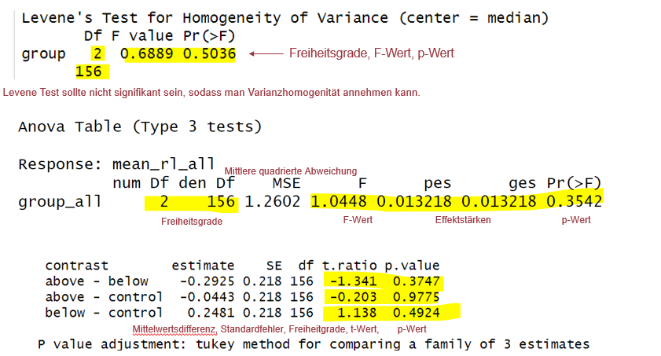

## ANOVA: Different Package - same result

**BASE-R**

```r
model_aov <- aov(mean_rl_all ~ group_all, data = dat_full)
summary(model_aov)
```

```
             Df Sum Sq Mean Sq F value Pr(>F)
group_all     2   2.63   1.317   1.045  0.354
Residuals   156 196.59   1.260
```

**aov_ez**

```r
model_aov_ez <- aov_ez(
  id = "code",
  dv = "mean_rl_all",
  between = "group_all",
  data = dat_full
)

summary(model_aov_ez)
```

```
Anova Table (Type 3 tests)

Response: mean_rl_all
          num Df den Df    MSE      F      ges Pr(>F)
group_all      2    156 1.2602 1.0448 0.013218 0.3542
```

## ANOVA: Effektstärken

generalisiertes **`η2`** & partielles **`η2`** - Wie viel Varianz wird durch die Gruppenzugehörigkeit erklärt?

```r
eta_squared(model_1, generalized = TRUE)
```

```
# Effect Size for ANOVA (Type III)

Parameter | Eta2 (generalized) |       95% CI
---------------------------------------------
group_all |               0.01 | [0.00, 1.00]

- Observed variables: All
- One-sided CIs: upper bound fixed at [1.00].
```

```r
eta_squared(model_1, partial = TRUE)
```

```
# Effect Size for ANOVA (Type III)

Parameter | Eta2 |       95% CI
-------------------------------
group_all | 0.01 | [0.00, 1.00]

- One-sided CIs: upper bound fixed at [1.00].
```

## Unterschiede generalisiertes und partielles η²

- Das generalisierte und `partielle` `η²`sind beides Masse, welche den **Anteil an erklärter Varianz** einer **abhängigen Variable** angeben.
- Das `generalisierte η²` berechnet den Anteil der erklärten Varianz einer abhängigen Variable unter **Einbezug der gesamten Varianz, also aller Effekte.**
- Das `partielle η²` beachtet bei der Berechnung des Anteils an erklärter Varianz für die **abhängige Variable nicht die gesamte Varianz**, sondern nur jene, welche dem **zuvor definierten Effekt** zugeschrieben werden kann.

## Post-Hoc t-Tests mit `pairs`

**Verschiedene Möglichkeiten**

- Klassische t-Tests, wie im Paper und in EH 12
- Schneller mit `pairs()`, womit alle möglichen Vergleiche simultan berechnet werden (aber ohne Effektstärken) –> Ergänzung für Fortgeschrittene im Hands-On!

```
 contrast        estimate    SE  df t.ratio p.value
 above - below    -0.2925 0.218 156  -1.341  0.3747
 above - control  -0.0443 0.218 156  -0.203  0.9775
 below - control   0.2481 0.218 156   1.138  0.4924

P value adjustment: tukey method for comparing a family of 3 estimates
```

- Optimalerweise: Präregistrieren, welche Post-Hoc-Tests berechnet werden und wie diese korrigiert werden sollen

## Korrektur für multiples Testen:

[figure not shown]

## Reminder 2x3 ANOVA

**AV** = Rating

**Between Subjects Faktor** = Feedbackgruppe (`below` vs. `control` vs. `above`)

**Within Subjects Faktor:** Messzeitpunkt (Messwiederholter Faktor, `pre 1` vs. `pre 4`)

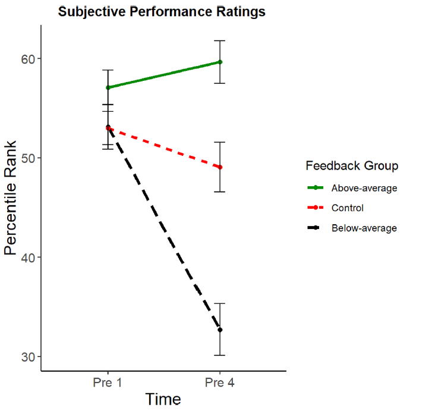

## 2x3 mixed ANOVA: Vorbereitungen

*Mixed-ANOVA mit `afex`*

**AV** = Rating

**Between Subjects Faktor** = Feedbackgruppe (`below` vs. `control` vs. `above`)

**Within Subjects Faktor:** Messzeitpunkt (Messwiederholter Faktor, `pre 1` vs. `pre 4`)

👉 Long Datensatz

*Muster:*

```r
mixed_anova <- aov_4(AV ~ between_factor + (messwiederholter_faktor | ID) data = dat_full_long)
```

## Beispielhafter Output mit **η2**

```r
mixed_anova <- aov_4(rating ~ group_all + (time_rating | code), data = dat_full_long, anova_table = list(es = c("ges" ,"pes")))


summary(mixed_anova)
```

```
Univariate Type III Repeated-Measures ANOVA Assuming Sphericity

                      Sum Sq num Df Error SS den Df  F value
(Intercept)           8198.9      1   500.58    156 2555.113
group_all              126.7      2   500.58    156   19.736
time_rating             42.0      1   288.70    156   22.668
group_all:time_rating   74.4      2   288.70    156   20.090
                                     Pr(>F)
(Intercept)           < 0.00000000000000022 ***
group_all                     0.00000002286 ***
time_rating                   0.00000436406 ***
group_all:time_rating         0.00000001724 ***
---
Signif. codes:  0 '***' 0.001 '**' 0.01 '*' 0.05 '.' 0.1 ' ' 1
```

```r
mixed_anova$anova_table
```

```
Anova Table (Type 3 tests)

Response: rating
                      num Df den Df    MSE      F     pes      ges
group_all                  2    156 3.2088 19.736 0.20193 0.138283
time_rating                1    156 1.8507 22.668 0.12687 0.050468
group_all:time_rating      2    156 1.8507 20.090 0.20481 0.086102
                             Pr(>F)
group_all             0.00000002286 ***
time_rating           0.00000436406 ***
group_all:time_rating 0.00000001724 ***
---
Signif. codes:  0 '***' 0.001 '**' 0.01 '*' 0.05 '.' 0.1 ' ' 1
```

```r
mixed_anova <- aov_4(rating ~ group_all + (time_rating | code), data = dat_full_long, anova_table = list(es = c("ges" ,"pes")))


summary(mixed_anova)
mixed_anova$anova_table
```

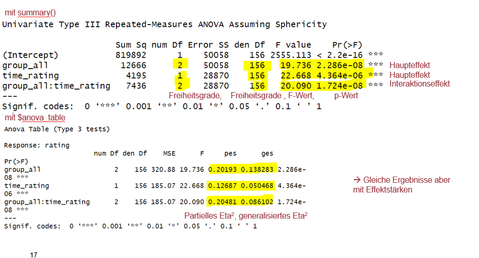

## Vergleich mit Grinschgl et al. (2021)

Im Paper wurde nur das reine **η2 berichtet. Berechnet mit `eta_squared()`** aus dem Package `effectsize`.

```
# Effect Size for ANOVA (Type III)

Parameter             | Eta2 |       95% CI
-------------------------------------------
group_all             | 0.12 | [0.05, 1.00]
time_rating           | 0.04 | [0.01, 1.00]
group_all:time_rating | 0.07 | [0.02, 1.00]

- One-sided CIs: upper bound fixed at [1.00].
```

We observed a main effect of the factor **“feedback group”, F(2, 156) = 19.74, p < 0.001, η2 = 0.12**, as well as a main effect of the factor “time of pre-rating”, **F(1, 156) = 22.67, p < 0.001, η2 = 0.04**. Most importantly, we also found a significant interaction between these factors, **F(2, 156) = 20.09, p < 0.001, η2 = 0.07**.

## Verletzungen der Voraussetzungen in ANOVAs

**Normalverteilung (one-way ANOVA)**

- `Kruskal-Wallis-Test` –> Besonders robust gegen Verletzungen der Normalverteilungsannahme

**Varianzhomogenität**

- Einfaktoriell: `Welch-ANOVA`

**Mixed ANOVA**

- Relativ robust gegenüber Verletzungen der Normalverteilung
- Robuste ANOVA mit `WRS2` Paket
- Multilevel Model mit `lme4`

Bei Grinschgl et al. (2021) wurde dies aber außer Acht gelassen. Auf jeden Fall sollte man sich im Vorfeld der Datenerhebung überlegen ob und wie man Voraussetzungen überprüft und wie man bei potenziellen Verletzungen vorgeht.

## Verletzung Sphärizität

**Beispiel aus den Daten Hausübung:**

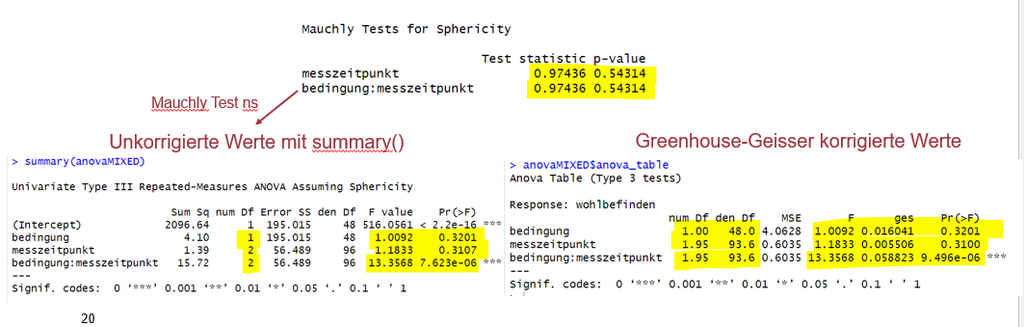

## Heute haben wir:

- ANOVAs kennengelernt
- Post-hoc Tests und Effektstärken berechnet
- Vorausetzungsprüfungen und Alternativen angeschaut

## Bis nächste Woche:

- **Muddiest Points!!** Bis Sonntag! siehe Ilias EH 13
- **Hausübung** bis Freitag **und Peerfeedback** bis Mittwoch**!**

Grinschgl, Sandra, Hauke S. Meyerhoff, Stephan Schwan, and Frank Papenmeier. 2021. “From Metacognitive Beliefs to Strategy Selection: Does Fake Performance Feedback Influence Cognitive Offloading?” *Psychological Research* 85 (7): 2654–66. https://doi.org/10.1007/s00426-020-01435-9.